# Network analysis of a northern long-eared bat (Myotis septentrionalis) maternity colony in a suburban forest patch | Journal of Urban Ecology | Oxford Academic

[figure not shown]

Volume 9

Issue 1

2023

### Article Contents

Journal Article

# Network analysis of a northern long-eared bat (*Myotis septentrionalis*) maternity colony in a suburban forest patch *Open Access*

Katherine M Gorman ,

Elaine L Barr ,

Tomás Nocera ,

W Mark Ford

*Journal of Urban Ecology*, Volume 9, Issue 1, 2023, juad005, https://doi.org/10.1093/jue/juad005

Published:

13 May 2023

## Abstract

Many bat species are highly social, forming groups of conspecifics, particularly during the maternity season. In temperate North America, these social groups are typically comprised of closely related individuals or individuals that share some common trait (i.e. reproductive state or shared hibernacula from the previous winter). In the summer, when bats use forests for day-roosts, these social groups often demonstrate nonrandom patterns of periodically associating in common roosts and disassociating using different roosts as a ‘fission–fusion society’. As cave hibernating bat species in North America continue to decline due to the impacts of White-nose Syndrome, opportunities to describe these dynamics are becoming rare. Unfortunately, these patterns often are still poorly documented, yet understanding these behaviors is critical for species-specific habitat conservation and management. In our study, we tracked female northern long-eared bats (*Myotis septentrionalis*) to their day-roosts in a small, suburban forest fragment in coastal New York, USA, in the summers of 2018 and 2019. We confirmed that the bats shared roost sites and, using network analyses, analyzed social dynamics and space use. In contrast to previous research on this imperiled species in large, unfragmented core forests, we found a more dense, connected roost network that concentrated around forest patch edges. Unusual for this species, primary roosts were anthropogenic structures. Our findings suggest that northern long-eared bats can utilize small forest patches and that incorporation of specific types of anthropogenic roosts might be an effective strategy for long-term conservation in more urbanized landscapes where forest management actions to enhance day-roosting conditions are impractical and the risk of stochastic loss of roosts is high.

## Introduction

Communal roosting is common among North American Vespertilionid bats throughout the year, with seasonal variation in social structures of those groups (Kerth 2008a). In the winter, many cave- and mine-hibernating bats cluster together in predominantly single-species aggregations (Davis 1970). In the summer, reproductive females will often further subdivide into colonies that are sometimes related along matrilines (Kerth 2008b; Patriquin et al. 2013; Silvis et al. 2014b; but see Olivera-Hyde et al. 2019). Social roosting of bats allows allonursing and communal rearing of young, thermoregulatory benefits, and information transfer (Kerth 2008a; Silvis et al. 2014b). However, one major disadvantage to communal roosting is the greater potential for disease transmission among conspecifics (Kerth 2008a; Johnson, Ford, and Edwards 2012). In North America, this has contributed to the spread of White-nose Syndrome (WNS), a disease caused by the invasive fungal pathogen *Pseudogymnoascus destructans* (*Pd;*Cheng et al. 2021). The transport of *Pd* fungal spores between hibernacula has resulted in population declines of >90% of several temperate-zone, cave-hibernating bats species (Powers et al. 2015; Cheng et al. 2021).

During the summer months in North America, several species of bats form maternity colonies in which frequent roost switching is well documented (Silvis et al. 2014a): bats from a larger group will sporadically disassociate into smaller groups, such as mother/juvenile pairs, and use secondary roosts while intermittently returning to primary colonial roosts. This type of roost switching behavior is characteristic of fission–fusion societies. Fission–fusion dynamics are present in many bat species (Kerth and Konig 1999; Willis and Brigham 2004; Patriquin et al. 2010; Johnson, Ford, and Edwards 2012; Silvis et al. 2014b) and network analyses have been used to identify structural vulnerabilities of the colony, and to provide researchers and managers with a better understanding of how a colony uses and moves around the landscape (Kerth 2008b; Chaverri 2010; Patriquin et al. 2010; Johnson, Ford, and Edwards 2012; Silvis et al. 2014b).

Northern long-eared bats (*Myotis septentrionalis*) are a federally-endangered species in eastern North America that display a fission–fusion dynamic during the temperate summer maternity season (Garroway and Broders 2007; Patriquin et al. 2010; Silvis et al. 2014a). Using network analysis metrics to describe bat roost-switching patterns and inter-individual relationships, these studies have thus far been conducted in largely closed-canopy, contiguous forests that contained an abundance of available roosts across an expansive spatial extent (Silvis et al. 2015; Ford et al. 2016). Regardless of geographic locale, patterns emerged among most colonies: communal node trees were identified and bats preferred one to two roosting companions when they disassociated from the larger colony (ranging from 12 to 88 individuals; Owen et al. 2002; Garroway and Broders 2007; Patriquin et al. 2010; Johnson, Ford, and Edwards 2012; Silvis et al. 2014a; Lewis et al. 2022). Unfortunately, because northern long-eared bats have experienced substantial population declines due to WNS, continued opportunities to study day-roost ecology of the species are becoming limited (Gorman et al. 2022a).

In this study, we explored the social dynamics of a post-WNS maternity colony in a comparatively more developed, coastal landscape in the mid-Atlantic region of the United States. Due to their volant nature and high vagility, in theory bats may be less constrained by habitat extent and connectivity than other terrestrial species. However, the demonstrated importance of social and familial relationships coupled with multi-year roost fidelity of northern long-eared bats may negatively affect individual dispersal or fusion of multiple colonies. In recent years, researchers have been finding northern long-eared bats in more urban and fragmented landscapes than what has previously been recorded for the species (Deeley 2019; Hoff et al., In review; Thorne et al. 2021). With northern long-eared bats maintaining social connectivity and reproductive success, even in areas with fragmented forests, understanding these populations could inform post-WNS adaptive management relative to varying landscape condition going forward (Rhodes et al. 2006; Snijders et al. 2017; Finch et al. 2022).

We hypothesized that a northern long-eared bat maternity colony in a highly-developed landscape would still display a general fission–fusion structure. However, given the more constrained, isolated nature of our study area’s forest patch and reduced populations from WNS, we predicted that there would be stronger connections between bats, proportionally more use of primary (high-density) roosts, and less use of secondary roosts. Further, we hypothesized that, though constrained overall by the small residual forest patch size, bats in this post-WNS colony would have a larger roost-area spatial footprint than observed in previous studies because suitable roosts may be relatively diffuse in a spatially constrained forest patch.

## Materials and methods

### Study area

Our study was conducted at the William Floyd Estate (hereafter, the Estate), a 248-ha coastal park on the southern shore of eastern Long Island, New York, USA, managed by the National Park Service (Fig. 1). It is located approximately equidistant between the northernmost and southernmost portions of the northern long-eared bat’s coastal distribution (Grider et al. 2016). Sixty-five percent of the Estate land is comprised of unmanaged, second- or third-growth oak (*Quercus* spp.)-dominated forest which is interspersed with open fields and salt marsh, fragmenting the forest habitat into several small patches (for a more detailed description see Klopfer et al. 2002 and Gorman et al. 2022a). Located approximately 100 km east of New York City, the Estate is surrounded by dense suburban neighborhoods to the north and west and the Atlantic Ocean to the south and east. Outside of the Estate, bats would need to fly a minimum of 3 km to reach additional forested habitat without having to cross open ocean, a distance greater than most observed mid-summer movements for northern long-eared bats (Henderson and Broders 2008). Long Island is frequently impacted by severe coastal weather events; overall, the climate is moderated by maritime influences, i.e. milder winters and cooler summers, than what interior New York State experiences (Gorman et al. 2021).

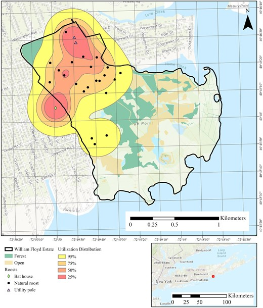

Figure 1:

Utilization distribution for northern long-eared bat (*Myotis septentrionalis*) maternity colony at the William Floyd Estate, New York (2018–9). Contour lines show 25%, 50%, 75%, and 95% utilization distributions. Utility poles and the bat house are shown as triangles and a diamond, respectively. Natural (tree) roosts are shown as points. Map created using ArcGIS<sup>®</sup> software by Esri. ArcGIS<sup>®</sup> and ArcMap™ are the intellectual property of Esri and are used herein under license. Copyright © Esri. All rights reserved. For more information about Esri<sup>®</sup> software, please visit [www.esri.com](http://www.esri.com/).

### Field work

We caught bats from May–June 2018 and May–July 2019 using 4–12 m length, 38 mm bat mist-nets (Avinet Research Supplies, Portland, ME, USA) (any use of trade, firm, or product names is for descriptive purposes only and does not imply endorsement by the U.S. Government) in single-, double-, and triple-high configurations over wooded roads and trails throughout the Estate (Silvis et al. 2012; Deeley 2019; Gorman et al. 2022a). After recording sex, age class (based on epiphyseal gap; Brunet-Rossinni and Wilkinson 2009), and weight, we fitted all northern long-eared bats with a uniquely-numbered aluminum alloy band (Porzana Ltd., Icklesham, East Sussex, UK). For subsequent radio-tracking, we affixed Holohil LB-2X VHF radio transmitters (0.27 g, lifespan 8–15 days; Holohil Systems Ltd., Carp, Ontario, Canada) between the scapulae with surgical cement (Perma-Type Company Inc., Plainville, CT, USA) to all adult female northern long-eared bats and one juvenile male weighing 6.2 g (Silvis et al. 2014a; Gorman et al. 2022b), ensuring that transmitters did not exceed >5% of the bat’s body mass (Aldridge and Brigham 1988). We tracked radio-tagged bats to their day-roosts using TRX-1000S receivers and folding three-element Yagi antennas (Wildlife Materials Inc., Carbondale, IL, USA) for the life of the transmitter, until it fell off, or until the bat could no longer be located three days in a row in the Estate or within 1.5 km of the boundary. When a roost was located, we georeferenced it with handheld GPS units (Garmin International Inc., Olathe, KS, USA). To maximize our potential of catching and radio-tagging bats within the same colony, we erected mist-nets around the located roost when cavities or loose bark were at or below the height of our triple-high net poles (approximately 7 m). Aberrant day-roosts such as utility poles were not netted for safety reasons. If weather permitted, we performed nightly emergence counts on each roost (Foster and Kurta 1999) to assess colony size. All handling of bats followed protocols approved by the Institutional Animal Care and Use Committee of the Virginia Polytechnic Institute and State University Protocol No. 19-227, and field work was conducted under the authority of permits issued by the New York Department of Environmental Conservation, National Park Service, and the U.S. Fish and Wildlife Service.

### Network analysis

We calculated distance between subsequently used roosts using the *sp* and *adehabitatHR* packages (Pebesma and Bivand 2005; Calenge 2006) in R (version 4.0.3; R Core Team 2021). We created a utilization distribution using a fixed kernel method to approximate space use by the colony. To generate a more realistic representation of the space use area relative to the intensity and concentration of roost use, we weighted each roost location by the number of days the roost was used and added anonymous bats to reflect the emergence count numbers on those days (Popa-Lisseanu et al. 2008; Silvis et al. 2014b). We used base Program R to calculate summary statistics for day-roosts: mean number of tracking days per bat, mean number of roosts used by each bat, mean relocations, individual bat roost switching frequency, and the number of times each roost was used throughout the tracking periods.

To characterize colony structure at the individual and community levels despite our disparate tracking periods, we used the *igraph* (Csardi and Nepusz 2006) and *tnet* (Opsahl 2009) packages. We then projected the two-mode network (bat to roost) into two one-mode networks (bat to bat and roost to roost). To describe network coherence, we calculated the mean degree, the degree centralization index, and the betweenness centrality index. Degree describes the distance between the nodes based on the number of other nodes with which they are in direct contact by dividing the network into ‘neighborhoods’ rather than considering the network as one unit (Oliveira and Gama 2012). Degree is a measure of connectivity and centrality (Freeman 1978; Dong and Horvath 2007), and a high degree value indicates that many individuals have a large number of connections (Newman and Park 2003). The degree centralization index and betweenness index are methods that use the node-level centrality scores to measure the difference between the node(s) with the most connections (degree) and the number of nodes that fall between two others (betweenness) against the centrality scores of rest of the group; these indexes range in value from 0 (low) to 1 (high; Freeman 1978). We used the UCINET software (Borgatti, Everett, and Freeman 2002) to explore the same network measures exclusive of betweenness and to create visualizations. We assessed the structures of the networks by calculating network densities and clustering for the entire two-mode network. Density compares the number of connected nodes (in this case, either bats or roosts) to the number of possible connections within the network (Scott et al. 2005). Higher density values for the bat network would mean more direct interaction, and perhaps stronger relationships, between individuals, whereas higher density values for the roost network would indicate the *potential* for direct interaction if the bats were to inhabit the nodes at the same time (Scott et al. 2005; Donati, Zappalà, and González-Romá 2016). The clustering coefficient measures how densely-packed or ‘cliquish’ the connections and nodes are and the extent whereby individual bats are known to one another (Scott et al. 2005; Dong and Horvath 2007; Opsahl and Panzarasa 2009; Opsahl 2013). We calculated clustering as a scaled 0 (low) to 1 (high) value following Silvis et al. (2014b).

## Results

Over both summers, we captured 20 individual northern long-eared bats (*n* = 16 total captures in 2018 and *n* = 6 total captures in 2019, including two recaptures from 2018; Table 1) over the course of 56 netting nights (*n* = 17 in 2018 and *n* = 39 in 2019). In 2018, one captured adult female had been banded during earlier monitoring efforts from 2015 and two bats escaped before transmitters could be affixed. Captures were higher in 2018 because we were able to net the bat house rather than relying solely on mist-netting. In 2019, two adult females from 2018 were recaptured as was a new female, a juvenile male and a juvenile female, and one adult male that was not tracked. Of the juveniles, only the male was large enough to receive a transmitter. From the 16 individuals with transmitters (12 females in 2018 only, two females in 2018 and 2019, one female in 2019 only, and one juvenile male in 2019 only) we documented 30 unique day-roosts—one of which was a utility pole used in both years. Three of the recorded day-roosts were anthropogenic structures (one bat house and two utility poles; Fig. 2), the remaining were live trees or snags of eight species or snags unidentifiable to species (Gorman et al. 2022a). All day-roosts we located were within the Estate boundary, except for the bat house that was located at a private residence approximately 80 m west of the Estate boundary. Twenty-one (ca. 70%) of these day-roosts were snags or declining live trees (Gorman et al. 2022a), six trees were alive, and the three anthropogenic roosts were not assigned a decay stage. Twenty-two emergence counts accounted for 1–11 exiting bats per roost on any given night.

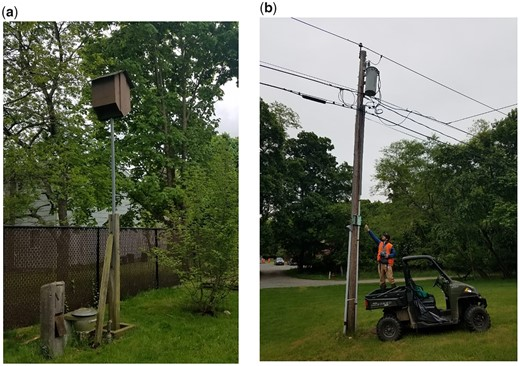

Figure 2:

[Left] Nursery box used by northern long-eared bat (*Myotis septentrionalis*) maternity colony just outside the William Floyd Estate, New York (2018). [Right] Utility pole used by northern long-eared bat maternity colony within the William Floyd Estate, New York (2018–9).

Table 1:

Dates and sites of northern long-eared (*Myotis septentrionalis*) captures at the William Floyd Estate, New York (2018–9)

| Bat | Capture date(s) | Capture site |
| --- | --- | --- |
| 72400 | 18 May 2018 | WIFLTR08 |
|  | 13 Jun 2018 | WIFLTR08 |
| 72401 | 18 May 2018 | West Gate |
|  | 12 Jun 2018 | WIFLTR04 |
|  | 13 Jun 2018 | West Gate |
| 72402 | 20 May 2018 | West Gate |
|  | 13 Jun 2018 | WIFLTR4 |
| 72403 | 20 May 2018 | West Gate |
|  | 13 Jun 2018 | WIFLTR04 |
| 72405 | 21 May 2018 | West Gate |
| 72406 | 13 Jun 2018 | WIFLTR04 |
|  | 16 Jun 2018 | WIFLTR08 |
|  | 22 Jun 2019 | West Gate |
| 72407 | 13 Jun 2018 | WIFLTR04 |
| 72408 | 13 Jun 2018 | WIFLTR04 |
| 72409 | 13 Jun 2018 | WIFLTR04 |
| 72410 | 13 Jun 2018 | WIFLTR04 |
| 72411 | 13 Jun 2018 | WIFLTR04 |
|  | 24 Jun 2019 | Visitor parking lot |
| 72412 | 13 Jun 2018 | WIFLTR04 |
| 72413 | 16 Jun 2018 | WIFLTR08 |
| 72414<sup>a</sup> | 19 May 2019 | West Gate |
| 72418<sup>a</sup> | 29 Jul 2019 | West Gate |
| RRR034 | 29 Jun 2015 | Unknown capture location |
|  | 16 Jun 2018 | Red and yellow trail intersection |

a

Bats 72414 and 72418 were presumably part of the colony but we did not have direct evidence of this connection for this study. As a result, they were not included in the network analysis.

WIFLTR04 (bat house) and WIFLTR08 (black locust [*Robinia pseudoacacia*]) were roosts that were netted. West Gate and visitor parking lot were net sites over paved roads. Red and yellow trail intersection was a net site at a four-way dirt trail intersection.

[output not shown]